# Introduction to `R`

This is the first of a series of notebooks with the principal ingredients of `r`.

These are some preliminary codes.

To see more of these notebooks [link](https://jmsevillam.github.io/R_basics/)

## Experiments

`R` allows us to *easily* simulate experiments such as coin toss experiments and visualize their results on a plot.

### Insights

If we want to simulate a coin toss experiment, with a fair coin (So that we have the same probability to get *heads* or *tails* ), we need to create a *variable* with those options (One can use just $0$ or $1$, but it is better if we want to have some visualizations).

First, as we only have two options or we get *Heads* or *Tails* (Neglecting the probability of the coin falling on vertical position), we create the *Output Space* which will be just a *collection* of two elements

```r
outspace= c("Head","Tail")
```

It is very important that we use the `c` before the parenthesis, this explicitly says, we are having a collection of things.

Then the experiment is basically throwing the coin several times, and evaluating the outputs, one can then, count how many are heads and how many tails.

`R` has a built-in function to do so, the function `sample` stands for *Random Samples and Permutations*, the official documentation describes as

> `sample` takes a sample of the specified size from the elements of `x` using either with or without replacement

To see more information, use on a code cell `?sample`.

We want to have this procedure several times (as many as throws), so for example let us explore this 20 times.

```r
z=sample(outspace,20,replace=TRUE)
```

The result of the sampling process is now saved on a variable `z`, to see it

```r
z
```

1. 'Tail'

2. 'Tail'

3. 'Head'

4. 'Tail'

5. 'Head'

6. 'Head'

7. 'Tail'

8. 'Tail'

9. 'Tail'

10. 'Tail'

11. 'Tail'

12. 'Head'

13. 'Head'

14. 'Head'

15. 'Head'

16. 'Head'

17. 'Head'

18. 'Head'

19. 'Tail'

20. 'Head'

Let us now, have more than $20$ experiments, and here, we are going to see a lot of structure that is natural on `R` (Also in other languages such as `python` because of their vectorized nature).

Suppose that we want to repeat this $5000$ times, but we want to have this value saved on a variable so that it can be easily changed

```r
n=5000 #Number of repetitions
```

Let us now, use the `sample` function, but $n$ times, and save the results on a variable. We don't have to save it, but as the output is very large, it is better to have it saved and visualize the results with a plot.

```r
outc= sample(outspace,n,replace=T)
```

Look that it is not necessary to have the complete word `TRUE`, with a `T` is enough.

Now, How can we count how many "Heads" we got? Look that we have saved on `outc` the output of the $5000$ repetitions of the experiment, let us print just $50$ of the outputs

```r
outc[0:50]
```

1. 'Tail'

2. 'Head'

3. 'Head'

4. 'Head'

5. 'Tail'

6. 'Tail'

7. 'Tail'

8. 'Head'

9. 'Head'

10. 'Tail'

11. 'Tail'

12. 'Head'

13. 'Tail'

14. 'Head'

15. 'Tail'

16. 'Head'

17. 'Head'

18. 'Tail'

19. 'Tail'

20. 'Tail'

21. 'Tail'

22. 'Head'

23. 'Head'

24. 'Tail'

25. 'Head'

26. 'Head'

27. 'Head'

28. 'Head'

29. 'Tail'

30. 'Tail'

31. 'Tail'

32. 'Tail'

33. 'Head'

34. 'Head'

35. 'Head'

36. 'Head'

37. 'Head'

38. 'Tail'

39. 'Tail'

40. 'Tail'

41. 'Head'

42. 'Head'

43. 'Tail'

44. 'Head'

45. 'Head'

46. 'Tail'

47. 'Tail'

48. 'Tail'

49. 'Tail'

50. 'Tail'

It is like a *list* of the outputs, and look, we can *ask* `R` wich one of them have the value `"Head"`

```r
outc[1:50]=="Head"
```

1. FALSE

2. TRUE

3. TRUE

4. TRUE

5. FALSE

6. FALSE

7. FALSE

8. TRUE

9. TRUE

10. FALSE

11. FALSE

12. TRUE

13. FALSE

14. TRUE

15. FALSE

16. TRUE

17. TRUE

18. FALSE

19. FALSE

20. FALSE

21. FALSE

22. TRUE

23. TRUE

24. FALSE

25. TRUE

26. TRUE

27. TRUE

28. TRUE

29. FALSE

30. FALSE

31. FALSE

32. FALSE

33. TRUE

34. TRUE

35. TRUE

36. TRUE

37. TRUE

38. FALSE

39. FALSE

40. FALSE

41. TRUE

42. TRUE

43. FALSE

44. TRUE

45. TRUE

46. FALSE

47. FALSE

48. FALSE

49. FALSE

50. FALSE

It is very important that we have used the double `==`, if we use one is an asignation but if we use two instead we get comparison.

It is commonly understood that the `TRUE` values are taken as $1$, and the `FALSE` values as $0$. (It is important that we HAVE to use the uppercase words true or false). So we can sum how many `TRUE` values we have until a certain component of the list, this is done with the `cumsum` function

```r
z=cumsum(outc=="Head")
```

For example, supose that you have the following list

```
[1,3,5,2,1]
```

The `cumsum` function should simply return something as

```
[1,4,9,11,12]
```

in other words, sum the values of the precedent cells.

```r
z[0:50]
```

1. 0

2. 1

3. 2

4. 3

5. 3

6. 3

7. 3

8. 4

9. 5

10. 5

11. 5

12. 6

13. 6

14. 7

15. 7

16. 8

17. 9

18. 9

19. 9

20. 9

21. 9

22. 10

23. 11

24. 11

25. 12

26. 13

27. 14

28. 15

29. 15

30. 15

31. 15

32. 15

33. 16

34. 17

35. 18

36. 19

37. 20

38. 20

39. 20

40. 20

41. 21

42. 22

43. 22

44. 23

45. 24

46. 24

47. 24

48. 24

49. 24

50. 24

As we do need to know how many times we got *Heads* compared with the number of throws, we divide by the position on the list, the function `seq` will be very useful in all our codes!, so it is convenient to look at it asap. Again, try `?seq`.

It basically creates a list of numbers.

The parameters are the initial and final points, but the difference between consecutive valies can be also given.

```r
seq(1,20)
```

1. 1

2. 2

3. 3

4. 4

5. 5

6. 6

7. 7

8. 8

9. 9

10. 10

11. 11

12. 12

13. 13

14. 14

15. 15

16. 16

17. 17

18. 18

19. 19

20. 20

```r
seq(1,20,0.8)
```

1. 1

2. 1.8

3. 2.6

4. 3.4

5. 4.2

6. 5

7. 5.8

8. 6.6

9. 7.4

10. 8.2

11. 9

12. 9.8

13. 10.6

14. 11.4

15. 12.2

16. 13

17. 13.8

18. 14.6

19. 15.4

20. 16.2

21. 17

22. 17.8

23. 18.6

24. 19.4

So, let us save the proportion of *heads* on a new list

```r
z=cumsum(outc=="Head")/seq(1,n)
```

```r
z[0:50]
```

1. 0

2. 0.5

3. 0.666666666666667

4. 0.75

5. 0.6

6. 0.5

7. 0.428571428571429

8. 0.5

9. 0.555555555555556

10. 0.5

11. 0.454545454545455

12. 0.5

13. 0.461538461538462

14. 0.5

15. 0.466666666666667

16. 0.5

17. 0.529411764705882

18. 0.5

19. 0.473684210526316

20. 0.45

21. 0.428571428571429

22. 0.454545454545455

23. 0.478260869565217

24. 0.458333333333333

25. 0.48

26. 0.5

27. 0.518518518518518

28. 0.535714285714286

29. 0.517241379310345

30. 0.5

31. 0.483870967741935

32. 0.46875

33. 0.484848484848485

34. 0.5

35. 0.514285714285714

36. 0.527777777777778

37. 0.540540540540541

38. 0.526315789473684

39. 0.512820512820513

40. 0.5

41. 0.51219512195122

42. 0.523809523809524

43. 0.511627906976744

44. 0.522727272727273

45. 0.533333333333333

46. 0.521739130434783

47. 0.51063829787234

48. 0.5

49. 0.489795918367347

50. 0.48

And let us plot this

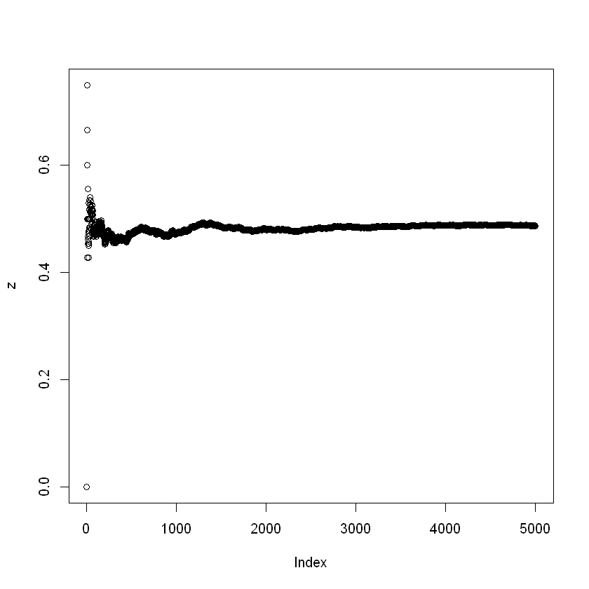

```r
plot(z)
```

Look that it looks that with the time, it gets closer to $0.5$, so let us put a line to visualize better,

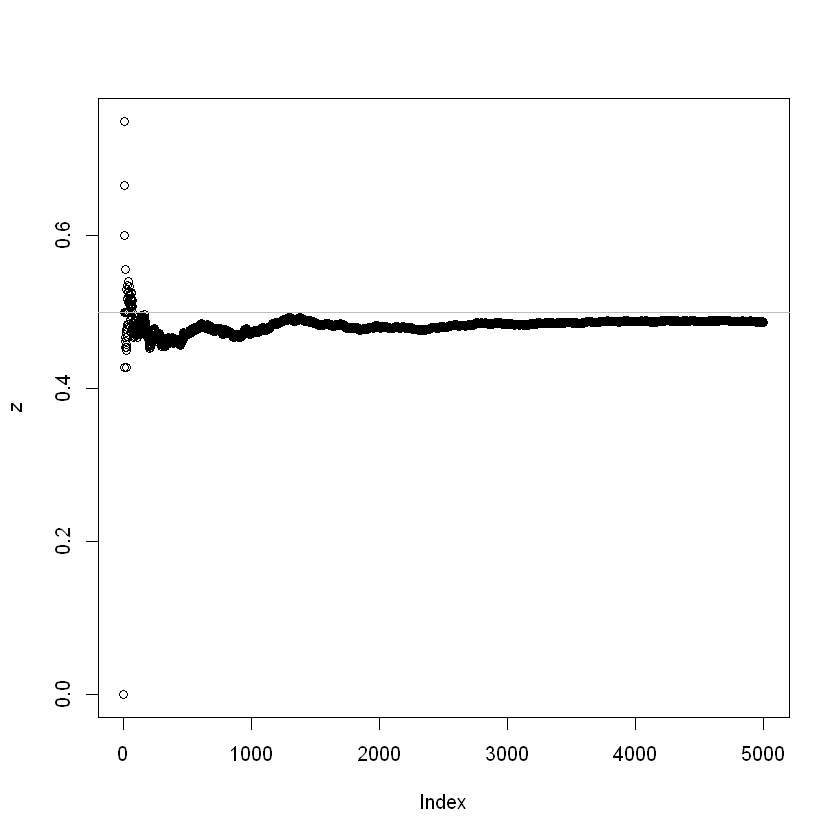

```r
plot(z)
abline(h=0.5, col="grey")
```

or we can change some values to make our plot to look better,

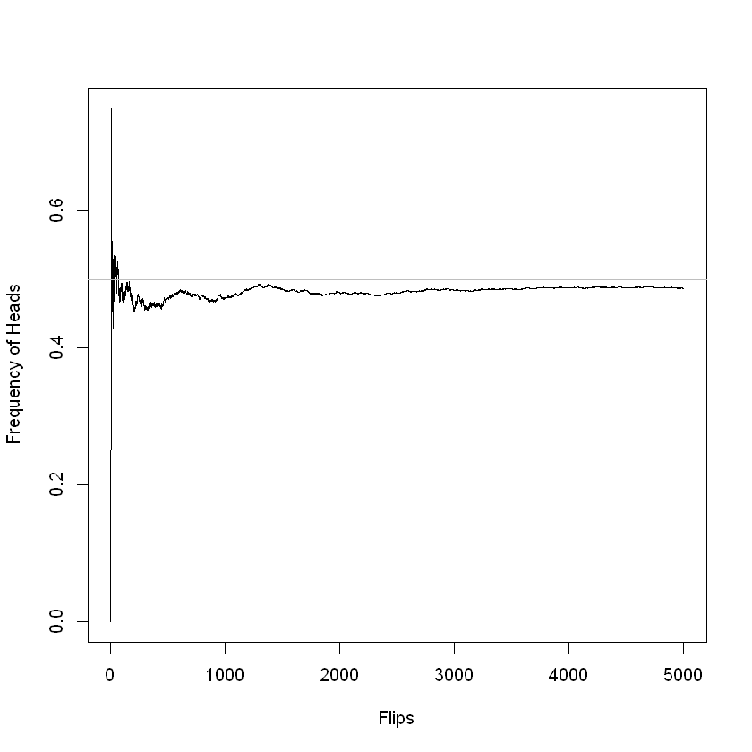

```r
plot(z, xlab="Flips", ylab="Frequency of Heads",type="l")
abline(h=0.5, col="grey")
```

```r
z1=cumsum(outc=="Head")/seq(1,n)
z2=cumsum(outc=="Tail")/seq(1,n)
```

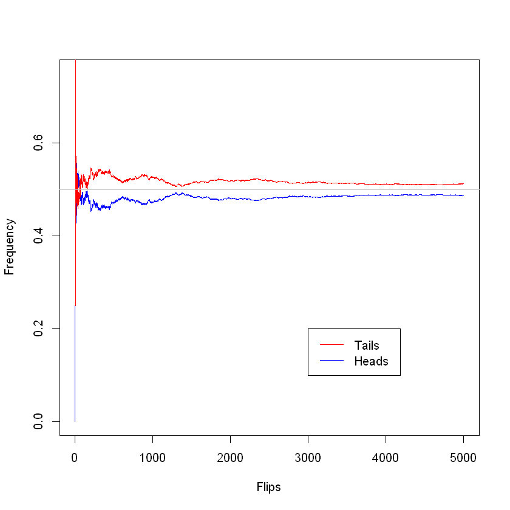

```r
plot(z1, col="blue", xlab="Flips", ylab="Frequency",type="l")
lines(z2,col="red")
abline(h=0.5, col="grey")
legend(3000, 0.2, legend=c("Tails", "Heads"),
       col=c("red", "blue"), lty=1:1)
```